# Prediction Assignment Writeup

# Background

Using devices such as Jawbone Up, Nike FuelBand, and Fitbit it is now possible to collect a large amount of data about personal activity relatively inexpensively. These type of devices are part of the quantified self movement â a group of enthusiasts who take measurements about themselves regularly to improve their health, to find patterns in their behavior, or because they are tech geeks. One thing that people regularly do is quantify how much of a particular activity they do, but they rarely quantify how well they do it. In this project, the goal was to use data from accelerometers on the belt, forearm, arm, and dumbell of 6 participants. They were asked to perform barbell lifts correctly and incorrectly in 5 different ways. More information is available from the website here: http://web.archive.org/web/20161224072740/http:/groupware.les.inf.puc-rio.br/har (see the section on the Weight Lifting Exercise Dataset).

Six young health participants were asked to perform one set of 10 repetitions of the Unilateral Dumbbell Biceps Curl in five different fashions: exactly according to the specification (Class A), throwing the elbows to the front (Class B), lifting the dumbbell only halfway (Class C), lowering the dumbbell only halfway (Class D) and throwing the hips to the front (Class E). Class A corresponds to the specified execution of the exercise, while the other 4 classes correspond to common mistakes.

The prediciton challenge is to apply the best machine learning algorithm to the 20 test cases available in the test data above and submit predictions in appropriate format to the Course Project Prediction Quiz for automated grading.

## Data

The training data for this project are available here: https://d396qusza40orc.cloudfront.net/predmachlearn/pml-training.csv The test data are available here: https://d396qusza40orc.cloudfront.net/predmachlearn/pml-testing.csv

# Load, Clean and Partition the Data

During the load we will interpret all blanks, “NA” and division errors as “NA” values. Data preparation will apply two principles:

1. Columns that sum to zero will be removed.
2. The first 7 columns of the data are master data (related to the user or timestamp) and therefore not relevant for the analysis, these will be removed.

```r
trainUrl <- "https://d396qusza40orc.cloudfront.net/predmachlearn/pml-training.csv"
testUrl <- "https://d396qusza40orc.cloudfront.net/predmachlearn/pml-testing.csv"

# All blanks, "NA" and division errors are interpreted as NA values
training <- read.csv(trainUrl, na.strings=c("NA","#DIV/0!",""))
testing <- read.csv(testUrl, na.strings=c("NA","#DIV/0!",""))

# delete columns with missing values
training <- training[, colSums(is.na(training)) == 0]
testing <- testing[, colSums(is.na(testing)) == 0]

# remove first 7 columns
training <- training[, -c(1:7)]
testing <- testing[, -c(1:7)]

# dim(training); dim(testing)

# partition the data
inTrain <- createDataPartition(training$classe, p=0.7, list = F)
train <- training[inTrain,]
validate <- training[-inTrain,]
```

The final dataset contains training data of 19622 rows and 53 columns. The test dataset is 20, 53. We have partitioned the training data into a training (70%) and validation set (30%).

# Prediction with a Decision Tree

First we’ll try using a decision tree to predict `classe`. We will cross-validate in order to sub-sample the training data, avoid overfitting and make the predictions generalizable:

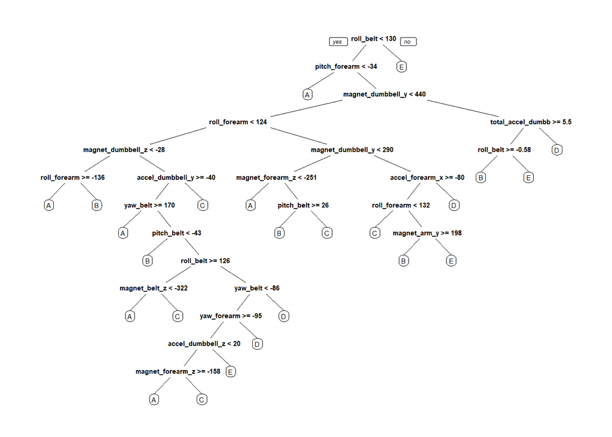

```r
set.seed(121)
control_rpart <- rpart.control(xval = 5)

# fit the model, cross-validated 5 times
fit_rpart <- rpart(classe ~ ., data = train, method = "class", control = control_rpart)
# note: we could have used caret
# model fitted on a mac where rattle won't load, will use rpart.plot()
prp(fit_rpart)
```

```r
# for further analysis, but not used in this report for brevity
# printcp(fit_rpart)

# prediction
predict_rpart <- predict(fit_rpart, validate, type = "class")
cm_rpart <- confusionMatrix(predict_rpart, validate$classe)
cm_rpart
```

```
## Confusion Matrix and Statistics
##
##           Reference
## Prediction    A    B    C    D    E
##          A 1454  176    9   38   12
##          B   50  645   59   87   75
##          C   39  127  873  145  118
##          D   72  101   79  625   61
##          E   59   90    6   69  816
##
## Overall Statistics
##
##                Accuracy : 0.7499
##                  95% CI : (0.7386, 0.7609)
##     No Information Rate : 0.2845
##     P-Value [Acc > NIR] : < 2.2e-16
##
##                   Kappa : 0.6838
##  Mcnemar's Test P-Value : < 2.2e-16
##
## Statistics by Class:
##
##                      Class: A Class: B Class: C Class: D Class: E
## Sensitivity            0.8686   0.5663   0.8509   0.6483   0.7542
## Specificity            0.9442   0.9429   0.9117   0.9364   0.9534
## Pos Pred Value         0.8609   0.7041   0.6705   0.6663   0.7846
## Neg Pred Value         0.9476   0.9006   0.9666   0.9315   0.9451
## Prevalence             0.2845   0.1935   0.1743   0.1638   0.1839
## Detection Rate         0.2471   0.1096   0.1483   0.1062   0.1387
## Detection Prevalence   0.2870   0.1556   0.2212   0.1594   0.1767
## Balanced Accuracy      0.9064   0.7546   0.8813   0.7924   0.8538
```

The accuracy of the decision tree is reasonably good, at 0.7499.

# Prediction with Random Forest

```r
control_rf <- trainControl(method="cv", number = 5, verboseIter = T)
# train with cv enabled
# fit_rf <- train(classe ~ ., data = train, method = "rf", trControl = control_rf)
# train without cv
fit_rf <- randomForest(classe ~ ., data = train)

print(fit_rf)
```

```
##
## Call:
##  randomForest(formula = classe ~ ., data = train)
##                Type of random forest: classification
##                      Number of trees: 500
## No. of variables tried at each split: 7
##
##         OOB estimate of  error rate: 0.54%
## Confusion matrix:
##      A    B    C    D    E  class.error
## A 3904    2    0    0    0 0.0005120328
## B   12 2642    4    0    0 0.0060195636
## C    0   15 2376    5    0 0.0083472454
## D    0    0   24 2225    3 0.0119893428
## E    0    0    2    7 2516 0.0035643564
```

```r
# prediction via caret
predict_rf <- predict(fit_rf, validate, type = "class")
cm_rf <- confusionMatrix(predict_rf, validate$classe)
cm_rf
```

```
## Confusion Matrix and Statistics
##
##           Reference
## Prediction    A    B    C    D    E
##          A 1674    2    0    0    0
##          B    0 1134    3    0    0
##          C    0    3 1023   16    2
##          D    0    0    0  948    2
##          E    0    0    0    0 1078
##
## Overall Statistics
##
##                Accuracy : 0.9952
##                  95% CI : (0.9931, 0.9968)
##     No Information Rate : 0.2845
##     P-Value [Acc > NIR] : < 2.2e-16
##
##                   Kappa : 0.994
##  Mcnemar's Test P-Value : NA
##
## Statistics by Class:
##
##                      Class: A Class: B Class: C Class: D Class: E
## Sensitivity            1.0000   0.9956   0.9971   0.9834   0.9963
## Specificity            0.9995   0.9994   0.9957   0.9996   1.0000
## Pos Pred Value         0.9988   0.9974   0.9799   0.9979   1.0000
## Neg Pred Value         1.0000   0.9989   0.9994   0.9968   0.9992
## Prevalence             0.2845   0.1935   0.1743   0.1638   0.1839
## Detection Rate         0.2845   0.1927   0.1738   0.1611   0.1832
## Detection Prevalence   0.2848   0.1932   0.1774   0.1614   0.1832
## Balanced Accuracy      0.9998   0.9975   0.9964   0.9915   0.9982
```

```r
# plot(fit_rf)
```

## Prediction with Test Data

The random forest outperforms the decision trees with accuracy of 0.9952421. We will therefore use it to predict the test data.

```r
predict_test <- predict(fit_rf, testing, type = "class")
predict_test
```

```
##  1  2  3  4  5  6  7  8  9 10 11 12 13 14 15 16 17 18 19 20
##  B  A  B  A  A  E  D  B  A  A  B  C  B  A  E  E  A  B  B  B
## Levels: A B C D E
```

# Appendix

1. Interpretation of RF and Confusion Matrix: https://www.youtube.com/watch?v=dJclNIN-TPo
2. R Markdown cheatsheet: https://www.rstudio.com/wp-content/uploads/2015/02/rmarkdown-cheatsheet.pdf
3. The caret package and cross-validation: https://cran.r-project.org/web/packages/caret/vignettes/caret.pdf
4. Cross-validation in R: https://www.youtube.com/watch?v=OwPQHmiJURI
5. Cross-validation Coursera: https://www.youtube.com/watch?v=CmEqvD_ov2o